# netflix_wajahath_zaman

Q8. Are family-oriented movies concentrated in specific genres ?

```python
movies_df
```

|  | title | director | country | date_added | release_year | rating_category | listed_in | duration_category |
| --- | --- | --- | --- | --- | --- | --- | --- | --- |
| 0 | Dick Johnson Is Dead | Kirsten Johnson | [United States] | 2021-09-25 | 2020 | Parental Guidance | [Documentaries] | Standard Film |
| 6 | My Little Pony: A New Generation | Robert Cullen, José Luis Ucha | [] | 2021-09-24 | 2021 | Parental Guidance | [Children & Family Movies] | Standard Film |
| 7 | Sankofa | Haile Gerima | [United States, Ghana, Burkina Faso, United Ki... | 2021-09-24 | 1993 | 17+ | [Dramas, Independent Movies, International Mov... | Long Film |
| 9 | The Starling | Theodore Melfi | [United States] | 2021-09-24 | 2021 | Parental Guidance | [Comedies, Dramas] | Standard Film |
| 12 | Je Suis Karl | Christian Schwochow | [Germany, Czech Republic] | 2021-09-23 | 2021 | 17+ | [Dramas, International Movies] | Long Film |
| ... | ... | ... | ... | ... | ... | ... | ... | ... |
| 8801 | Zinzana | Majid Al Ansari | [United Arab Emirates, Jordan] | 2016-03-09 | 2015 | 17+ | [Dramas, International Movies, Thrillers] | Standard Film |
| 8802 | Zodiac | David Fincher | [United States] | 2019-11-20 | 2007 | 17+ | [Cult Movies, Dramas, Thrillers] | Epic Film |
| 8804 | Zombieland | Ruben Fleischer | [United States] | 2019-11-01 | 2009 | 17+ | [Comedies, Horror Movies] | Standard Film |
| 8805 | Zoom | Peter Hewitt | [United States] | 2020-01-11 | 2006 | Parental Guidance | [Children & Family Movies, Comedies] | Standard Film |
| 8806 | Zubaan | Mozez Singh | [India] | 2019-03-02 | 2015 | 14+ | [Dramas, International Movies, Music & Musicals] | Standard Film |

5939 rows × 8 columns

```python
family_vs_genre = movies_df[['rating_category', 'listed_in']]
```

```python
family_vs_genre = family_vs_genre.explode('listed_in')
```

```python
family_vs_genre['rating_category'].unique()
```

```
array(['Parental Guidance', '17+', '14+', 'Unknown', 'General',
       'Not Rated'], dtype=object)
```

```python
family_rating = ['Parental_Guidance', 'General']
family_vs_genre = family_vs_genre[family_vs_genre['rating_category'].isin(family_rating)]
```

```python
family_vs_genre = family_vs_genre.groupby(['listed_in'])['listed_in'].size().reset_index(name='count').sort_values(by="count", ascending=False).head(10)
```

```python
family_vs_genre
```

|  | listed_in | count |
| --- | --- | --- |
| 2 | Children & Family Movies | 79 |
| 9 | International Movies | 51 |
| 5 | Documentaries | 44 |
| 4 | Comedies | 40 |
| 6 | Dramas | 30 |
| 11 | Music & Musicals | 23 |
| 12 | Romantic Movies | 15 |
| 3 | Classic Movies | 9 |
| 14 | Sports Movies | 7 |
| 10 | Movies | 3 |

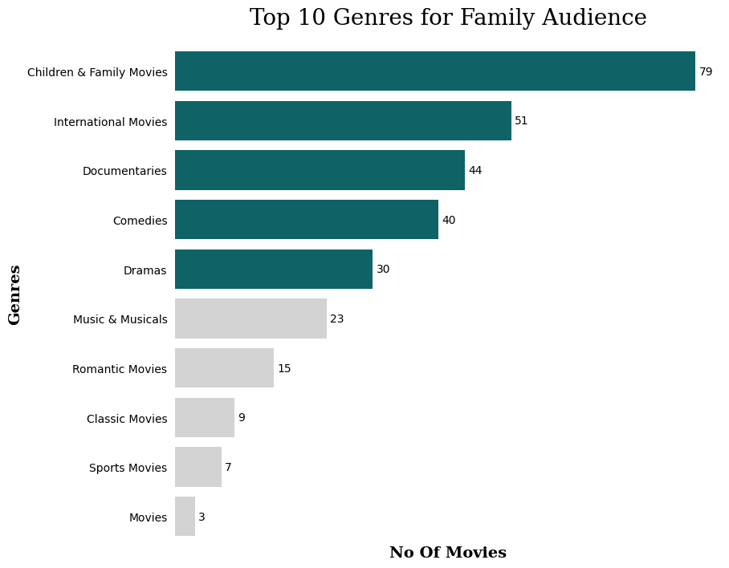

```python
plt.figure(figsize=(10,8))

colors = [
    '#007074' if i < 5 else 'lightgray'
    for i in range(len(global_genres))
]


ax = sns.barplot(
    data=family_vs_genre,
    x='count',
    y='listed_in',
    hue='listed_in',
    palette=colors
)
plt.title("Top 10 Genres for Family Audience", fontsize=20, pad=20, fontfamily='serif')

plt.ylabel('Genres' , fontweight='bold', fontsize=14, fontfamily='serif')
plt.xlabel('No Of Movies', fontweight='bold', fontsize=14, fontfamily='serif')

sns.despine(left=True, bottom=True)
ax.tick_params(left=False, bottom=False)
ax.set_xticks([])

ax.spines['bottom'].set_visible(False)

plt.tight_layout(pad=4)

for i in ax.containers:
  ax.bar_label(i, fmt="{:,.0f}", padding=3 )

plt.show()
```

Q9. Are standard films dominant golbally ?

```python
movies_df
```

|  | title | director | country | date_added | release_year | rating_category | listed_in | duration_category |
| --- | --- | --- | --- | --- | --- | --- | --- | --- |
| 0 | Dick Johnson Is Dead | Kirsten Johnson | [United States] | 2021-09-25 | 2020 | Parental Guidance | [Documentaries] | Standard Film |
| 6 | My Little Pony: A New Generation | Robert Cullen, José Luis Ucha | [] | 2021-09-24 | 2021 | Parental Guidance | [Children & Family Movies] | Standard Film |
| 7 | Sankofa | Haile Gerima | [United States, Ghana, Burkina Faso, United Ki... | 2021-09-24 | 1993 | 17+ | [Dramas, Independent Movies, International Mov... | Long Film |
| 9 | The Starling | Theodore Melfi | [United States] | 2021-09-24 | 2021 | Parental Guidance | [Comedies, Dramas] | Standard Film |
| 12 | Je Suis Karl | Christian Schwochow | [Germany, Czech Republic] | 2021-09-23 | 2021 | 17+ | [Dramas, International Movies] | Long Film |
| ... | ... | ... | ... | ... | ... | ... | ... | ... |
| 8801 | Zinzana | Majid Al Ansari | [United Arab Emirates, Jordan] | 2016-03-09 | 2015 | 17+ | [Dramas, International Movies, Thrillers] | Standard Film |
| 8802 | Zodiac | David Fincher | [United States] | 2019-11-20 | 2007 | 17+ | [Cult Movies, Dramas, Thrillers] | Epic Film |
| 8804 | Zombieland | Ruben Fleischer | [United States] | 2019-11-01 | 2009 | 17+ | [Comedies, Horror Movies] | Standard Film |
| 8805 | Zoom | Peter Hewitt | [United States] | 2020-01-11 | 2006 | Parental Guidance | [Children & Family Movies, Comedies] | Standard Film |
| 8806 | Zubaan | Mozez Singh | [India] | 2019-03-02 | 2015 | 14+ | [Dramas, International Movies, Music & Musicals] | Standard Film |

5939 rows × 8 columns

```python
global_duration = movies_df.groupby('duration_category').size().reset_index(name='Count').sort_values('duration_category', ascending=False)
```

```python
global_duration['percentage'] = round(global_duration['Count'] * 100 / global_duration['Count'].sum())
```

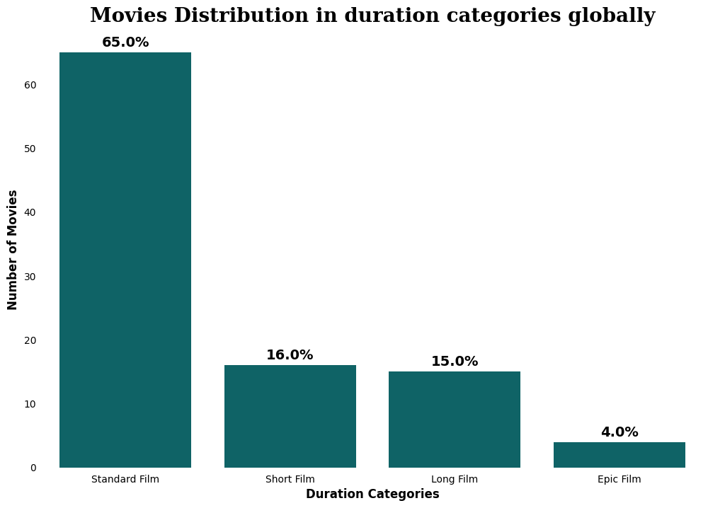

```python
plt.figure(figsize = (12,8))

ax = sns.barplot(
    data=global_duration,
    x='duration_category',
    y="percentage",
    color="#007074"
)

sns.despine(left=True, bottom=True)
ax.tick_params(left=False, bottom=False)

plt.title("Movies Distribution in duration categories globally", fontsize=20, fontweight='semibold', fontfamily="serif", pad=10)
plt.xlabel("Duration Categories", fontsize=12, fontweight='semibold')
plt.ylabel('Number of Movies', fontsize=12, fontweight='semibold')


for container in ax.containers:
    ax.bar_label(container, padding=3, fontweight='semibold', fontsize=14, fmt="%0.1f%%")

plt.show()
```

- Standard-length films dominate globally at around 65%, which shows that Netflix mainly relies on regular-duration movies as the primary format. This suggests that standard films are considered the safest and most widely accepted format across audiences.
- Short Films (16%) and Long Films (15%) have almost similar representation, meaning there is some diversity in movie duration, but they are still much smaller compared to standard films. This indicates that alternative formats exist but are not the main focus.

Q10. Has movie duration preference changed over release year ?

```python
movies_df['decade'] = (movies_df['release_year'] // 10) * 10


duration_counts = (
    movies_df
    .groupby(['decade', 'duration_category'])
    .size()
    .reset_index(name='count')
)

duration_counts['percentage'] = (
    duration_counts
    .groupby('decade')['count']
    .transform(lambda x: x * 100/ x.sum())
)
```

```python
# Calculate total percentage across decades
order = (
    duration_counts
    .groupby('duration_category')['percentage']
    .sum()
    .sort_values(ascending=False)
    .index
)
```

```python
# Create decreasing line widths
linewidths = [4, 3, 2]  # adjust depending on number of categories

lw_dict = dict(zip(order, linewidths))
```

```python
import numpy as np

linewidths = np.linspace(4, 1.5, len(order))
lw_dict = dict(zip(order, linewidths))
```

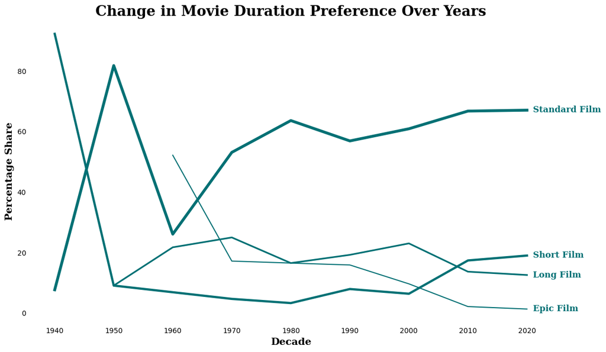

```python
plt.figure(figsize=(12,7))

for category in order:

    subset = (
        duration_counts[
            duration_counts['duration_category'] == category
        ]
        .sort_values('decade')
    )

    plt.plot(
        subset['decade'],
        subset['percentage'],
        color="#007074",
        linewidth=lw_dict[category]
    )

    # Get last point
    last_x = subset['decade'].iloc[-1]
    last_y = subset['percentage'].iloc[-1]

    # Add label beside line
    plt.text(
        last_x + 1,        # small shift to right
        last_y,
        category,
        fontsize=12,
        fontfamily='serif',
        fontweight='semibold',
        color="#007074",
        va='center'
    )

plt.title("Change in Movie Duration Preference Over Years",
          fontsize=20,
          fontfamily='serif',
          fontweight='semibold')

plt.ylabel("Percentage Share",
           fontsize=14,
           fontfamily='serif',
           fontweight='semibold')

plt.xlabel("Decade",
           fontsize=14,
           fontfamily='serif',
           fontweight='semibold')

sns.despine(left=True, bottom=True)
plt.tick_params(left=False, bottom=False)

plt.tight_layout()
plt.show()
```

### TV Shows - Dataframe

```python
tv_df.head()
```

|  | show_id | type | title | director | cast | country | date_added | release_year | rating | duration | listed_in | description |
| --- | --- | --- | --- | --- | --- | --- | --- | --- | --- | --- | --- | --- |
| 1 | s2 | TV Show | Blood & Water | NaN | Ama Qamata, Khosi Ngema, Gail Mabalane, Thaban... | South Africa | September 24, 2021 | 2021 | TV-MA | 2 Seasons | International TV Shows, TV Dramas, TV Mysteries | After crossing paths at a party, a Cape Town t... |
| 2 | s3 | TV Show | Ganglands | Julien Leclercq | Sami Bouajila, Tracy Gotoas, Samuel Jouy, Nabi... | NaN | September 24, 2021 | 2021 | TV-MA | 1 Season | Crime TV Shows, International TV Shows, TV Act... | To protect his family from a powerful drug lor... |
| 3 | s4 | TV Show | Jailbirds New Orleans | NaN | NaN | NaN | September 24, 2021 | 2021 | TV-MA | 1 Season | Docuseries, Reality TV | Feuds, flirtations and toilet talk go down amo... |
| 4 | s5 | TV Show | Kota Factory | NaN | Mayur More, Jitendra Kumar, Ranjan Raj, Alam K... | India | September 24, 2021 | 2021 | TV-MA | 2 Seasons | International TV Shows, Romantic TV Shows, TV ... | In a city of coaching centers known to train I... |
| 5 | s6 | TV Show | Midnight Mass | Mike Flanagan | Kate Siegel, Zach Gilford, Hamish Linklater, H... | NaN | September 24, 2021 | 2021 | TV-MA | 1 Season | TV Dramas, TV Horror, TV Mysteries | The arrival of a charismatic young priest brin... |

```python
tv_df.info()
```

```
<class 'pandas.core.frame.DataFrame'>
Index: 2676 entries, 1 to 8803
Data columns (total 12 columns):
 #   Column        Non-Null Count  Dtype
---  ------        --------------  -----
 0   show_id       2676 non-null   object
 1   type          2676 non-null   object
 2   title         2676 non-null   object
 3   director      230 non-null    object
 4   cast          2326 non-null   object
 5   country       2285 non-null   object
 6   date_added    2666 non-null   object
 7   release_year  2676 non-null   int64
 8   rating        2674 non-null   object
 9   duration      2676 non-null   object
 10  listed_in     2676 non-null   object
 11  description   2676 non-null   object
dtypes: int64(1), object(11)
memory usage: 271.8+ KB
```

The column wise information:

1. Directors column has very less data making it useless for analysis, dropped it.
2. Cast column is irrelevant with respect to business problem, dropping it as well.
3. Similarly there is no use of description column in our analysis.

```python
tv_df = tv_df[['show_id', 'title', 'country', 'date_added','release_year', 'rating', 'duration', 'listed_in']]
```

```python
tv_df.info()
```

```
<class 'pandas.core.frame.DataFrame'>
Index: 2676 entries, 1 to 8803
Data columns (total 8 columns):
 #   Column        Non-Null Count  Dtype
---  ------        --------------  -----
 0   show_id       2676 non-null   object
 1   title         2676 non-null   object
 2   country       2285 non-null   object
 3   date_added    2666 non-null   object
 4   release_year  2676 non-null   int64
 5   rating        2674 non-null   object
 6   duration      2676 non-null   object
 7   listed_in     2676 non-null   object
dtypes: int64(1), object(7)
memory usage: 188.2+ KB
```

Missing Values:

```python
# For some Tv shows the countries are more than one so we will have to convert this to list later. Temporarily we will fill the missing values with empty string.
tv_df['country'] = tv_df['country'].fillna('')
```

```python
# For date_added, rating the missing values are very less so dropping those rows.
tv_df = tv_df.dropna(subset=['date_added'])
tv_df = tv_df.dropna(subset=['rating'])
```

```python
tv_df.info()
```

```
<class 'pandas.core.frame.DataFrame'>
Index: 2664 entries, 1 to 8803
Data columns (total 8 columns):
 #   Column        Non-Null Count  Dtype
---  ------        --------------  -----
 0   show_id       2664 non-null   object
 1   title         2664 non-null   object
 2   country       2664 non-null   object
 3   date_added    2664 non-null   object
 4   release_year  2664 non-null   int64
 5   rating        2664 non-null   object
 6   duration      2664 non-null   object
 7   listed_in     2664 non-null   object
dtypes: int64(1), object(7)
memory usage: 187.3+ KB
```

Missing values are handled. Lets check for duplicates.

```python
tv_df.duplicated().sum()
```

```
np.int64(0)
```

```python
tv_df.duplicated(subset=['country', 'title']).sum()
```

```
np.int64(0)
```

There are no duplicates found. But there are some inconsistencies in data types of the columns.

```python
tv_df.info()
```

```
<class 'pandas.core.frame.DataFrame'>
Index: 2664 entries, 1 to 8803
Data columns (total 8 columns):
 #   Column        Non-Null Count  Dtype
---  ------        --------------  -----
 0   show_id       2664 non-null   object
 1   title         2664 non-null   object
 2   country       2664 non-null   object
 3   date_added    2664 non-null   object
 4   release_year  2664 non-null   int64
 5   rating        2664 non-null   object
 6   duration      2664 non-null   object
 7   listed_in     2664 non-null   object
dtypes: int64(1), object(7)
memory usage: 187.3+ KB
```

```python
tv_df.head()
```

|  | show_id | title | country | date_added | release_year | rating | duration | listed_in |
| --- | --- | --- | --- | --- | --- | --- | --- | --- |
| 1 | s2 | Blood & Water | South Africa | September 24, 2021 | 2021 | TV-MA | 2 Seasons | International TV Shows, TV Dramas, TV Mysteries |
| 2 | s3 | Ganglands |  | September 24, 2021 | 2021 | TV-MA | 1 Season | Crime TV Shows, International TV Shows, TV Act... |
| 3 | s4 | Jailbirds New Orleans |  | September 24, 2021 | 2021 | TV-MA | 1 Season | Docuseries, Reality TV |
| 4 | s5 | Kota Factory | India | September 24, 2021 | 2021 | TV-MA | 2 Seasons | International TV Shows, Romantic TV Shows, TV ... |
| 5 | s6 | Midnight Mass |  | September 24, 2021 | 2021 | TV-MA | 1 Season | TV Dramas, TV Horror, TV Mysteries |

```python
tv_df['country'] = tv_df['country'].apply(
    lambda x: [country.strip() for country in x.split(',')] if x else []
)
```

```python
# Changing the datatype of date_added column

tv_df['date_added'] = tv_df['date_added'].str.strip()
tv_df['date_added'] = pd.to_datetime(tv_df['date_added'], format="%B %d, %Y")
```

```python
tv_df.head()
```

|  | show_id | title | country | date_added | release_year | rating | duration | listed_in |
| --- | --- | --- | --- | --- | --- | --- | --- | --- |
| 1 | s2 | Blood & Water | [South Africa] | 2021-09-24 | 2021 | TV-MA | 2 Seasons | International TV Shows, TV Dramas, TV Mysteries |
| 2 | s3 | Ganglands | [] | 2021-09-24 | 2021 | TV-MA | 1 Season | Crime TV Shows, International TV Shows, TV Act... |
| 3 | s4 | Jailbirds New Orleans | [] | 2021-09-24 | 2021 | TV-MA | 1 Season | Docuseries, Reality TV |
| 4 | s5 | Kota Factory | [India] | 2021-09-24 | 2021 | TV-MA | 2 Seasons | International TV Shows, Romantic TV Shows, TV ... |
| 5 | s6 | Midnight Mass | [] | 2021-09-24 | 2021 | TV-MA | 1 Season | TV Dramas, TV Horror, TV Mysteries |

```python
tv_df.head()
```

|  | show_id | title | country | date_added | release_year | rating | duration | listed_in |
| --- | --- | --- | --- | --- | --- | --- | --- | --- |
| 1 | s2 | Blood & Water | [South Africa] | 2021-09-24 | 2021 | TV-MA | 2 Seasons | International TV Shows, TV Dramas, TV Mysteries |
| 2 | s3 | Ganglands | [] | 2021-09-24 | 2021 | TV-MA | 1 Season | Crime TV Shows, International TV Shows, TV Act... |
| 3 | s4 | Jailbirds New Orleans | [] | 2021-09-24 | 2021 | TV-MA | 1 Season | Docuseries, Reality TV |
| 4 | s5 | Kota Factory | [India] | 2021-09-24 | 2021 | TV-MA | 2 Seasons | International TV Shows, Romantic TV Shows, TV ... |
| 5 | s6 | Midnight Mass | [] | 2021-09-24 | 2021 | TV-MA | 1 Season | TV Dramas, TV Horror, TV Mysteries |

```python
# Converting the string values in listed_in column into lists.
tv_df['listed_in'].isna().sum()
```

```
np.int64(0)
```

```python
tv_df['listed_in'] = tv_df['listed_in'].apply(
    lambda x: [genre.strip() for genre in x.split(',')] if x else []
)
```

```python
tv_df['no_of_seasons'] = tv_df['duration'].str.extract('(\d+)').astype(int)
```

```python
# Final analytics ready TV show data set:

tv_df = tv_df[['show_id', 'title', 'country', 'date_added', 'release_year', 'listed_in', 'duration', 'no_of_seasons']]

tv_df.head(10)

# The country and listed_in columns will be used in data analytics when needed.
```

|  | show_id | title | country | date_added | release_year | listed_in | duration | no_of_seasons |
| --- | --- | --- | --- | --- | --- | --- | --- | --- |
| 1 | s2 | Blood & Water | [South Africa] | 2021-09-24 | 2021 | [International TV Shows, TV Dramas, TV Mysteries] | 2 Seasons | 2 |
| 2 | s3 | Ganglands | [] | 2021-09-24 | 2021 | [Crime TV Shows, International TV Shows, TV Ac... | 1 Season | 1 |
| 3 | s4 | Jailbirds New Orleans | [] | 2021-09-24 | 2021 | [Docuseries, Reality TV] | 1 Season | 1 |
| 4 | s5 | Kota Factory | [India] | 2021-09-24 | 2021 | [International TV Shows, Romantic TV Shows, TV... | 2 Seasons | 2 |
| 5 | s6 | Midnight Mass | [] | 2021-09-24 | 2021 | [TV Dramas, TV Horror, TV Mysteries] | 1 Season | 1 |
| 8 | s9 | The Great British Baking Show | [United Kingdom] | 2021-09-24 | 2021 | [British TV Shows, Reality TV] | 9 Seasons | 9 |
| 10 | s11 | Vendetta: Truth, Lies and The Mafia | [] | 2021-09-24 | 2021 | [Crime TV Shows, Docuseries, International TV ... | 1 Season | 1 |
| 11 | s12 | Bangkok Breaking | [] | 2021-09-23 | 2021 | [Crime TV Shows, International TV Shows, TV Ac... | 1 Season | 1 |
| 14 | s15 | Crime Stories: India Detectives | [] | 2021-09-22 | 2021 | [British TV Shows, Crime TV Shows, Docuseries] | 1 Season | 1 |
| 15 | s16 | Dear White People | [United States] | 2021-09-22 | 2021 | [TV Comedies, TV Dramas] | 4 Seasons | 4 |

```python
tv_df.info()
```

```
<class 'pandas.core.frame.DataFrame'>
Index: 2664 entries, 1 to 8803
Data columns (total 8 columns):
 #   Column         Non-Null Count  Dtype
---  ------         --------------  -----
 0   show_id        2664 non-null   object
 1   title          2664 non-null   object
 2   country        2664 non-null   object
 3   date_added     2664 non-null   datetime64[ns]
 4   release_year   2664 non-null   int64
 5   listed_in      2664 non-null   object
 6   duration       2664 non-null   object
 7   no_of_seasons  2664 non-null   int64
dtypes: datetime64[ns](1), int64(2), object(5)
memory usage: 187.3+ KB
```

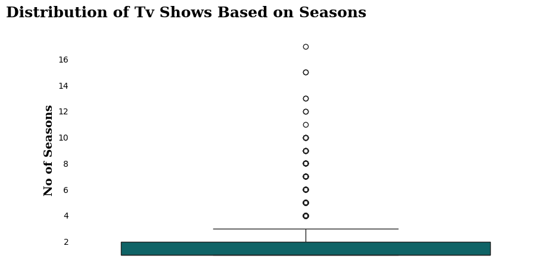

```python
# Plotting boxplot for seasons_count as all other columns are categorical columns.
fig, ax = plt.subplots(figsize=(10,5))

sns.boxplot(
    data = tv_df,
    y="no_of_seasons",
    color='#007074'
)

fig.suptitle("Distribution of Tv Shows Based on Seasons", fontsize=18, fontweight='semibold', fontfamily='serif', ha='left', x=0.01)


sns.despine(left=True, bottom=True)
ax.tick_params(left=False, bottom=False)

plt.ylabel("No of Seasons", fontsize=14, fontfamily='serif', fontweight='semibold')
plt.show()
```

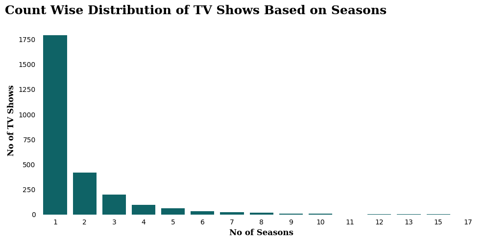

```python
fig, ax = plt.subplots(figsize=(10,5))

sns.countplot(
    data=tv_df,
    x='no_of_seasons',
    color="#007074",
    ax=ax
)

# Figure-level title aligned fully left
fig.suptitle(
    "Count Wise Distribution of TV Shows Based on Seasons",
    fontsize=18,
    fontweight='semibold',
    fontfamily='serif',
    x=0.01,     # move fully left (0 = extreme left)
    ha='left'
)

sns.despine(left=True, bottom=True)
ax.tick_params(left=False, bottom=False)

plt.ylabel("No of TV Shows", fontsize=12, fontfamily='serif', fontweight='semibold')
plt.xlabel("No of Seasons", fontsize=12, fontfamily='serif', fontweight='semibold')


plt.tight_layout()
plt.show()
```

- It can be understood that majority of TV shows are produced for only 1 Season, where as only few are continued to 2 and 3 seasons.
- There are some rare events where the TV shows are made for almost 10 and 15 seasons as well. But this is very small compared to the majority.
- Similar fact can be infered from the boxplot whisker as well. Majority of the TV shows are launched for 1,2 seasons only.

## Data Analysis [ TV shows ]

```python
tv_df.describe().T
```

|  | count | mean | min | 25% | 50% | 75% | max | std |
| --- | --- | --- | --- | --- | --- | --- | --- | --- |
| date_added | 2664 | 2019-06-10 00:15:40.540540672 | 2008-02-04 00:00:00 | 2018-04-27 00:00:00 | 2019-08-16 00:00:00 | 2020-10-01 00:00:00 | 2021-09-24 00:00:00 | NaN |
| release_year | 2664.0 | 2016.627628 | 1925.0 | 2016.0 | 2018.0 | 2020.0 | 2021.0 | 5.735194 |
| no_of_seasons | 2664.0 | 1.751877 | 1.0 | 1.0 | 1.0 | 2.0 | 17.0 | 1.550622 |

```python
tv_df.info()
```

```
<class 'pandas.core.frame.DataFrame'>
Index: 2664 entries, 1 to 8803
Data columns (total 8 columns):
 #   Column         Non-Null Count  Dtype
---  ------         --------------  -----
 0   show_id        2664 non-null   object
 1   title          2664 non-null   object
 2   country        2664 non-null   object
 3   date_added     2664 non-null   datetime64[ns]
 4   release_year   2664 non-null   int64
 5   listed_in      2664 non-null   object
 6   duration       2664 non-null   object
 7   no_of_seasons  2664 non-null   int64
dtypes: datetime64[ns](1), int64(2), object(5)
memory usage: 187.3+ KB
```

```python
tv_df.head(10)
```

|  | show_id | title | country | date_added | release_year | listed_in | duration | no_of_seasons |
| --- | --- | --- | --- | --- | --- | --- | --- | --- |
| 1 | s2 | Blood & Water | [South Africa] | 2021-09-24 | 2021 | [International TV Shows, TV Dramas, TV Mysteries] | 2 Seasons | 2 |
| 2 | s3 | Ganglands | [] | 2021-09-24 | 2021 | [Crime TV Shows, International TV Shows, TV Ac... | 1 Season | 1 |
| 3 | s4 | Jailbirds New Orleans | [] | 2021-09-24 | 2021 | [Docuseries, Reality TV] | 1 Season | 1 |
| 4 | s5 | Kota Factory | [India] | 2021-09-24 | 2021 | [International TV Shows, Romantic TV Shows, TV... | 2 Seasons | 2 |
| 5 | s6 | Midnight Mass | [] | 2021-09-24 | 2021 | [TV Dramas, TV Horror, TV Mysteries] | 1 Season | 1 |
| 8 | s9 | The Great British Baking Show | [United Kingdom] | 2021-09-24 | 2021 | [British TV Shows, Reality TV] | 9 Seasons | 9 |
| 10 | s11 | Vendetta: Truth, Lies and The Mafia | [] | 2021-09-24 | 2021 | [Crime TV Shows, Docuseries, International TV ... | 1 Season | 1 |
| 11 | s12 | Bangkok Breaking | [] | 2021-09-23 | 2021 | [Crime TV Shows, International TV Shows, TV Ac... | 1 Season | 1 |
| 14 | s15 | Crime Stories: India Detectives | [] | 2021-09-22 | 2021 | [British TV Shows, Crime TV Shows, Docuseries] | 1 Season | 1 |
| 15 | s16 | Dear White People | [United States] | 2021-09-22 | 2021 | [TV Comedies, TV Dramas] | 4 Seasons | 4 |

Q1. Which countries produce the most TV shows ?

```python
country_vs_shows = tv_df[['country', 'title']]
```

```python
country_vs_shows = country_vs_shows.explode('country')
country_vs_shows = country_vs_shows.fillna('Unknown')
```

```python
country_vs_shows.head()
```

|  | country | title |
| --- | --- | --- |
| 1 | South Africa | Blood & Water |
| 2 | Unknown | Ganglands |
| 3 | Unknown | Jailbirds New Orleans |
| 4 | India | Kota Factory |
| 5 | Unknown | Midnight Mass |

```python
country_vs_shows = country_vs_shows.groupby('country')['title'].count().reset_index(name='count').sort_values('count', ascending=False)
```

```python
top_15_countries_for_shows = country_vs_shows.head(15)
top_15_countries_for_shows
```

|  | country | count |
| --- | --- | --- |
| 63 | United States | 932 |
| 64 | Unknown | 390 |
| 62 | United Kingdom | 271 |
| 30 | Japan | 197 |
| 52 | South Korea | 170 |
| 8 | Canada | 126 |
| 19 | France | 90 |
| 25 | India | 84 |
| 57 | Taiwan | 70 |
| 2 | Australia | 64 |
| 53 | Spain | 61 |
| 38 | Mexico | 58 |
| 10 | China | 48 |
| 20 | Germany | 44 |
| 11 | Colombia | 32 |

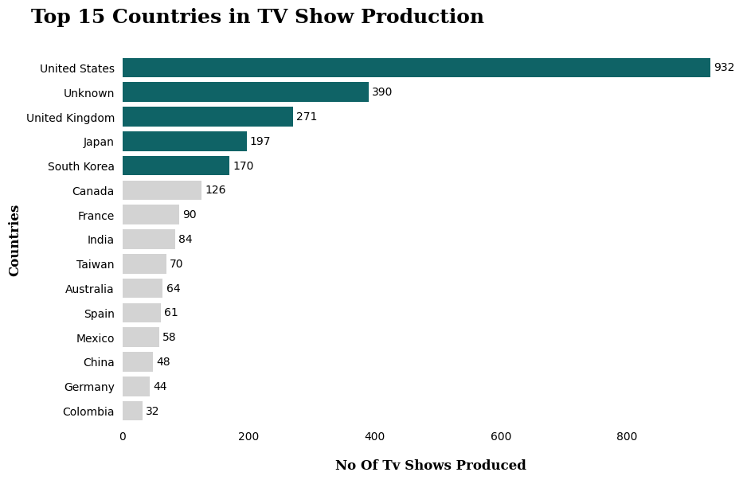

```python
fig, ax = plt.subplots(figsize=(10,6))

colors = [
    "#007074" if i < 5 else "lightgray"
    for i in range(len(top_15_countries_for_shows))
]

fig.suptitle(
    "Top 15 Countries in TV Show Production",
    fontsize=18,
    fontweight='semibold',
    fontfamily='serif',
    ha='left',
    x=0.01
)

sns.barplot(
    data=top_15_countries_for_shows,
    x='count',
    y='country',
    hue='country',
    palette = colors
)

# TO-DO : ADD text later

sns.despine(left=True, bottom=True)
ax.tick_params(left=False, bottom=False)

for container in ax.containers:
  ax.bar_label(container, padding=3)

plt.xlabel("No Of Tv Shows Produced",fontweight="semibold" , fontsize=12, fontfamily='serif' , labelpad=15)
plt.ylabel("Countries", fontsize=12, fontfamily='serif', fontweight="semibold")

plt.show()
```

```python
top_5_countries_tv_shows = top_15_countries_for_shows.head()
top_10_countries_tv_shows = top_15_countries_for_shows.head(10)
percentage = top_5_countries_tv_shows['count'].sum() * 100 / top_15_countries_for_shows['count'].sum()


percentage_top5_entire_data = round(top_5_countries_tv_shows['count'].sum() * 100 / tv_df.explode('country')['title'].count())
percentage_top10_entire_data = round(top_10_countries_tv_shows['count'].sum() * 100 / tv_df.explode('country')['title'].count())
percentage_top15_entire_data = round(top_15_countries_for_shows['count'].sum() * 100 / tv_df.explode('country')['title'].count())

print(f"Percentage of Entire Tv Show data Contributed by Top 5 countries: {percentage_top5_entire_data} %")
print(f"Percentage of Entire Tv Show data Contributed by Top 10 countries: {percentage_top10_entire_data} %")
print(f"Percentage of Entire Tv Show data Contributed by Top 15 countries: {percentage_top15_entire_data} %")
```

```
Percentage of Entire Tv Show data Contributed by Top 5 countries: 65 %
Percentage of Entire Tv Show data Contributed by Top 10 countries: 79 %
Percentage of Entire Tv Show data Contributed by Top 15 countries: 87 %
```

- The United States dominates TV show production by a very large margin compared to all other countries, which shows that Netflix still heavily relies on US-produced series as the core of its TV content strategy.
- Asian countries like Japan and South Korea appear strongly in the top producers list, even ahead of many European countries. This suggests that Asian markets are becoming important hubs for TV show production and possibly strong drivers of global audience engagement.
- There is a sharp drop after the top few countries, meaning TV production is more concentrated geographically compared to movies. This indicates that Netflix’s TV strategy is less distributed and may offer expansion opportunities in underrepresented but growing markets.

Q2. What are the top genres in tv shows per country ?

```python
top_15_countries_for_shows
```

|  | country | count |
| --- | --- | --- |
| 63 | United States | 932 |
| 64 | Unknown | 390 |
| 62 | United Kingdom | 271 |
| 30 | Japan | 197 |
| 52 | South Korea | 170 |
| 8 | Canada | 126 |
| 19 | France | 90 |
| 25 | India | 84 |
| 57 | Taiwan | 70 |
| 2 | Australia | 64 |
| 53 | Spain | 61 |
| 38 | Mexico | 58 |
| 10 | China | 48 |
| 20 | Germany | 44 |
| 11 | Colombia | 32 |

```python
tv_df_exploded = tv_df.explode('country')
tv_df_exploded = tv_df_exploded.fillna('Unknown')
tv_df_exploded
```

|  | show_id | title | country | date_added | release_year | listed_in | duration | no_of_seasons |
| --- | --- | --- | --- | --- | --- | --- | --- | --- |
| 1 | s2 | Blood & Water | South Africa | 2021-09-24 | 2021 | [International TV Shows, TV Dramas, TV Mysteries] | 2 Seasons | 2 |
| 2 | s3 | Ganglands | Unknown | 2021-09-24 | 2021 | [Crime TV Shows, International TV Shows, TV Ac... | 1 Season | 1 |
| 3 | s4 | Jailbirds New Orleans | Unknown | 2021-09-24 | 2021 | [Docuseries, Reality TV] | 1 Season | 1 |
| 4 | s5 | Kota Factory | India | 2021-09-24 | 2021 | [International TV Shows, Romantic TV Shows, TV... | 2 Seasons | 2 |
| 5 | s6 | Midnight Mass | Unknown | 2021-09-24 | 2021 | [TV Dramas, TV Horror, TV Mysteries] | 1 Season | 1 |
| ... | ... | ... | ... | ... | ... | ... | ... | ... |
| 8797 | s8798 | Zak Storm | France | 2018-09-13 | 2016 | [Kids' TV] | 3 Seasons | 3 |
| 8797 | s8798 | Zak Storm | South Korea | 2018-09-13 | 2016 | [Kids' TV] | 3 Seasons | 3 |
| 8797 | s8798 | Zak Storm | Indonesia | 2018-09-13 | 2016 | [Kids' TV] | 3 Seasons | 3 |
| 8800 | s8801 | Zindagi Gulzar Hai | Pakistan | 2016-12-15 | 2012 | [International TV Shows, Romantic TV Shows, TV... | 1 Season | 1 |
| 8803 | s8804 | Zombie Dumb | Unknown | 2019-07-01 | 2018 | [Kids' TV, Korean TV Shows, TV Comedies] | 2 Seasons | 2 |

3019 rows × 8 columns

```python
top_15_countries_tv_shows_full_data = tv_df_exploded[tv_df_exploded['country'].isin(top_15_countries_for_shows['country'])]
```

```python
top_15_countries_tv_shows_full_data
```

|  | show_id | title | country | date_added | release_year | listed_in | duration | no_of_seasons |
| --- | --- | --- | --- | --- | --- | --- | --- | --- |
| 2 | s3 | Ganglands | Unknown | 2021-09-24 | 2021 | [Crime TV Shows, International TV Shows, TV Ac... | 1 Season | 1 |
| 3 | s4 | Jailbirds New Orleans | Unknown | 2021-09-24 | 2021 | [Docuseries, Reality TV] | 1 Season | 1 |
| 4 | s5 | Kota Factory | India | 2021-09-24 | 2021 | [International TV Shows, Romantic TV Shows, TV... | 2 Seasons | 2 |
| 5 | s6 | Midnight Mass | Unknown | 2021-09-24 | 2021 | [TV Dramas, TV Horror, TV Mysteries] | 1 Season | 1 |
| 8 | s9 | The Great British Baking Show | United Kingdom | 2021-09-24 | 2021 | [British TV Shows, Reality TV] | 9 Seasons | 9 |
| ... | ... | ... | ... | ... | ... | ... | ... | ... |
| 8795 | s8796 | Yu-Gi-Oh! Arc-V | Canada | 2018-05-01 | 2015 | [Anime Series, Kids' TV] | 2 Seasons | 2 |
| 8797 | s8798 | Zak Storm | United States | 2018-09-13 | 2016 | [Kids' TV] | 3 Seasons | 3 |
| 8797 | s8798 | Zak Storm | France | 2018-09-13 | 2016 | [Kids' TV] | 3 Seasons | 3 |
| 8797 | s8798 | Zak Storm | South Korea | 2018-09-13 | 2016 | [Kids' TV] | 3 Seasons | 3 |
| 8803 | s8804 | Zombie Dumb | Unknown | 2019-07-01 | 2018 | [Kids' TV, Korean TV Shows, TV Comedies] | 2 Seasons | 2 |

2637 rows × 8 columns

```python
country_vs_genre_shows = top_15_countries_tv_shows_full_data[['country','listed_in']]
country_vs_genre_shows = country_vs_genre_shows.explode('listed_in')
country_vs_genre_shows = country_vs_genre_shows.groupby(['country', 'listed_in']).size().reset_index(name='count').sort_values(['count', 'listed_in'], ascending=[False,False])
```

```python
country_vs_genre_shows
```

|  | country | listed_in | count |
| --- | --- | --- | --- |
| 208 | United States | TV Comedies | 253 |
| 209 | United States | TV Dramas | 232 |
| 176 | United Kingdom | British TV Shows | 224 |
| 221 | Unknown | International TV Shows | 223 |
| 200 | United States | Kids' TV | 214 |
| ... | ... | ... | ... |
| 52 | Colombia | Docuseries | 1 |
| 218 | Unknown | Classic & Cult TV | 1 |
| 108 | Japan | British TV Shows | 1 |
| 0 | Australia | Anime Series | 1 |
| 150 | Spain | Anime Series | 1 |

238 rows × 3 columns

```python
top_3_genres_shows_per_country = (
    country_vs_genre_shows
    .assign(
        rank=lambda x: x.groupby('country')['count'].rank(method='first', ascending=False)
    )
    .query( 'rank <= 3' )
    .sort_values(['country', 'rank'])
)
```

```python
top_3_genres_shows_per_country
```

|  | country | listed_in | count | rank |
| --- | --- | --- | --- | --- |
| 4 | Australia | International TV Shows | 31 | 1.0 |
| 11 | Australia | TV Dramas | 19 | 2.0 |
| 5 | Australia | Kids' TV | 19 | 3.0 |
| 23 | Canada | Kids' TV | 61 | 1.0 |
| 30 | Canada | TV Dramas | 32 | 2.0 |
| 29 | Canada | TV Comedies | 30 | 3.0 |
| 40 | China | International TV Shows | 40 | 1.0 |
| 44 | China | Romantic TV Shows | 22 | 2.0 |
| 47 | China | TV Dramas | 20 | 3.0 |
| 53 | Colombia | International TV Shows | 31 | 1.0 |
| 55 | Colombia | Spanish-Language TV Shows | 30 | 2.0 |
| 51 | Colombia | Crime TV Shows | 18 | 3.0 |
| 64 | France | Kids' TV | 43 | 1.0 |
| 63 | France | International TV Shows | 43 | 2.0 |
| 71 | France | TV Dramas | 27 | 3.0 |
| 79 | Germany | International TV Shows | 35 | 1.0 |
| 87 | Germany | TV Dramas | 19 | 2.0 |
| 77 | Germany | Crime TV Shows | 15 | 3.0 |
| 93 | India | International TV Shows | 66 | 1.0 |
| 100 | India | TV Dramas | 28 | 2.0 |
| 99 | India | TV Comedies | 26 | 3.0 |
| 111 | Japan | International TV Shows | 150 | 1.0 |
| 107 | Japan | Anime Series | 141 | 2.0 |
| 112 | Japan | Kids' TV | 29 | 3.0 |
| 131 | Mexico | Spanish-Language TV Shows | 47 | 1.0 |
| 127 | Mexico | International TV Shows | 43 | 2.0 |
| 125 | Mexico | Crime TV Shows | 32 | 3.0 |
| 138 | South Korea | International TV Shows | 152 | 1.0 |
| 140 | South Korea | Korean TV Shows | 132 | 2.0 |
| 142 | South Korea | Romantic TV Shows | 77 | 3.0 |
| 154 | Spain | International TV Shows | 54 | 1.0 |
| 159 | Spain | Spanish-Language TV Shows | 41 | 2.0 |
| 152 | Spain | Crime TV Shows | 27 | 3.0 |
| 165 | Taiwan | International TV Shows | 70 | 1.0 |
| 167 | Taiwan | Romantic TV Shows | 48 | 2.0 |
| 169 | Taiwan | TV Comedies | 36 | 3.0 |
| 176 | United Kingdom | British TV Shows | 224 | 1.0 |
| 180 | United Kingdom | International TV Shows | 128 | 2.0 |
| 179 | United Kingdom | Docuseries | 89 | 3.0 |
| 208 | United States | TV Comedies | 253 | 1.0 |
| 209 | United States | TV Dramas | 232 | 2.0 |
| 200 | United States | Kids' TV | 214 | 3.0 |
| 221 | Unknown | International TV Shows | 223 | 1.0 |
| 231 | Unknown | TV Dramas | 100 | 2.0 |
| 230 | Unknown | TV Comedies | 80 | 3.0 |

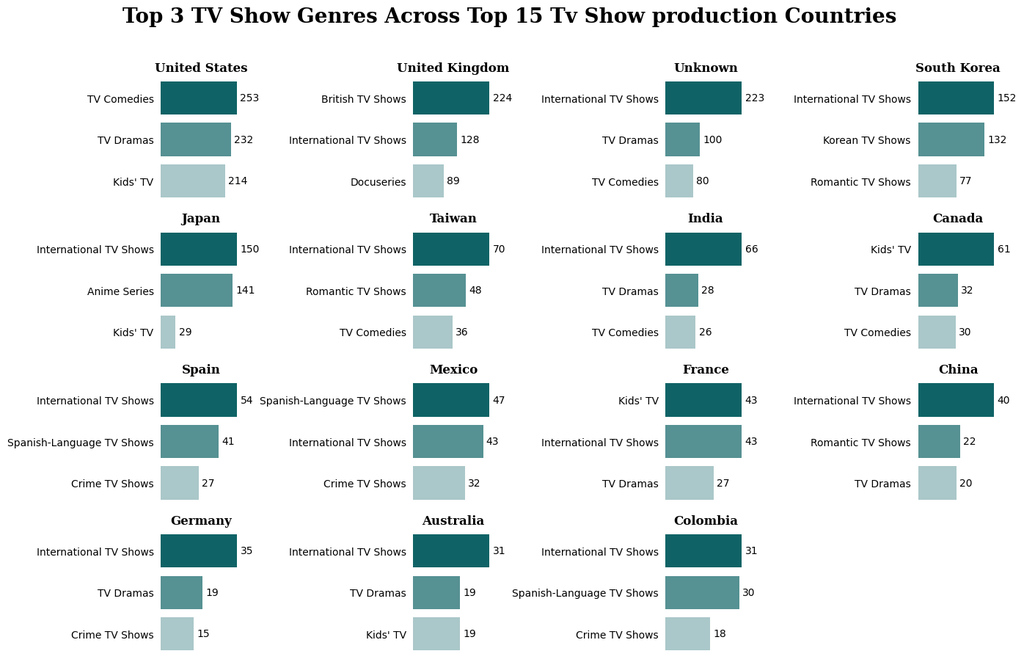

```python
# Get unique countries from your ranked dataframe
countries = (
    top_3_genres_shows_per_country
    .sort_values(['count', 'country', 'rank'], ascending=[False, True, True])['country']
    .unique()
)

# Grid layout
n_cols = 4
n_rows = int(np.ceil(len(countries) / n_cols))

fig, axes = plt.subplots(n_rows, n_cols, figsize=(14, 2.2 * n_rows))
axes = axes.flatten()

for i, country in enumerate(countries):

    # Filter country data
    data = (
        top_3_genres_shows_per_country[
            top_3_genres_shows_per_country['country'] == country
        ]
        .sort_values('rank')   # ensure rank 1,2,3 order
    )

    # Rank-based color hierarchy
    colors = ['#007074', '#4C9A9D', '#A5CCCE']

    sns.barplot(
        data=data,
        x='count',
        y='listed_in',
        hue='listed_in',
        ax=axes[i],
        palette=colors
    )

    # Country title
    axes[i].set_title(
        country,
        fontsize=12,
        fontweight='bold',
        fontfamily='serif'
    )

    # Clean axes
    axes[i].set_xlabel('')
    axes[i].set_ylabel('')
    axes[i].set_xticks([])

    sns.despine(ax=axes[i], left=True, bottom=True)
    axes[i].tick_params(left=False, bottom=False)

    # Add bar labels
    for container in axes[i].containers:
        axes[i].bar_label(container, fmt='%d', padding=3)

# Remove unused empty axes
for j in range(i + 1, len(axes)):
    fig.delaxes(axes[j])

# Overall title
plt.suptitle(
    "Top 3 TV Show Genres Across Top 15 Tv Show production Countries",
    fontsize=20,
    fontweight='bold',
    fontfamily="serif",
    y=1.02
)

plt.tight_layout()
plt.show()
```

- International TV Shows appear in the top three genres for almost every country, which shows that Netflix heavily depends on globally adaptable TV content to reach wider audiences across regions.
- The United States and United Kingdom focus more on TV Comedies, TV Dramas, and region-specific content (like British TV Shows), while countries like South Korea and Japan show strong presence of culturally specific genres such as Korean TV Shows and Anime Series. This suggests that TV content is more locally customized compared to movies.
- Some countries like Canada and France show strong presence of Kids’ TV in their top genres, indicating that certain markets may have stronger family or younger audience demand for TV shows compared to others.

Q3. What are the most common TV genres globally ?

```python
tv_df_genre_exploded = tv_df.explode('listed_in')
tv_df_genre_exploded
```

|  | show_id | title | country | date_added | release_year | listed_in | duration | no_of_seasons |
| --- | --- | --- | --- | --- | --- | --- | --- | --- |
| 1 | s2 | Blood & Water | [South Africa] | 2021-09-24 | 2021 | International TV Shows | 2 Seasons | 2 |
| 1 | s2 | Blood & Water | [South Africa] | 2021-09-24 | 2021 | TV Dramas | 2 Seasons | 2 |
| 1 | s2 | Blood & Water | [South Africa] | 2021-09-24 | 2021 | TV Mysteries | 2 Seasons | 2 |
| 2 | s3 | Ganglands | [] | 2021-09-24 | 2021 | Crime TV Shows | 1 Season | 1 |
| 2 | s3 | Ganglands | [] | 2021-09-24 | 2021 | International TV Shows | 1 Season | 1 |
| ... | ... | ... | ... | ... | ... | ... | ... | ... |
| 8800 | s8801 | Zindagi Gulzar Hai | [Pakistan] | 2016-12-15 | 2012 | Romantic TV Shows | 1 Season | 1 |
| 8800 | s8801 | Zindagi Gulzar Hai | [Pakistan] | 2016-12-15 | 2012 | TV Dramas | 1 Season | 1 |
| 8803 | s8804 | Zombie Dumb | [] | 2019-07-01 | 2018 | Kids' TV | 2 Seasons | 2 |
| 8803 | s8804 | Zombie Dumb | [] | 2019-07-01 | 2018 | Korean TV Shows | 2 Seasons | 2 |
| 8803 | s8804 | Zombie Dumb | [] | 2019-07-01 | 2018 | TV Comedies | 2 Seasons | 2 |

6109 rows × 8 columns

```python
global_genre_shows = (
    tv_df_genre_exploded
    .groupby('listed_in')['title'].count()
    .reset_index(name='count')
    .sort_values('count', ascending=False)
)
```

```python
global_genre_shows
```

|  | listed_in | count |
| --- | --- | --- |
| 5 | International TV Shows | 1349 |
| 15 | TV Dramas | 762 |
| 14 | TV Comedies | 573 |
| 3 | Crime TV Shows | 469 |
| 6 | Kids' TV | 448 |
| 4 | Docuseries | 394 |
| 9 | Romantic TV Shows | 370 |
| 8 | Reality TV | 255 |
| 1 | British TV Shows | 252 |
| 0 | Anime Series | 174 |
| 11 | Spanish-Language TV Shows | 173 |
| 13 | TV Action & Adventure | 167 |
| 7 | Korean TV Shows | 151 |
| 17 | TV Mysteries | 98 |
| 10 | Science & Nature TV | 92 |
| 18 | TV Sci-Fi & Fantasy | 83 |
| 16 | TV Horror | 75 |
| 21 | Teen TV Shows | 69 |
| 20 | TV Thrillers | 57 |
| 12 | Stand-Up Comedy & Talk Shows | 56 |
| 2 | Classic & Cult TV | 26 |
| 19 | TV Shows | 16 |

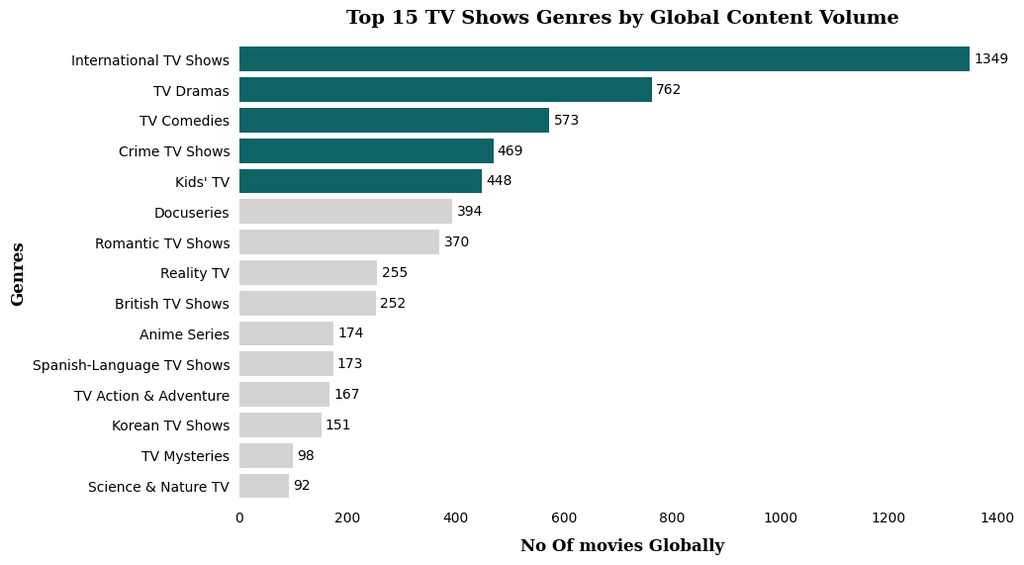

```python
plt.figure(figsize=(10,6))

colors = [
    "#007074" if i < 5 else "lightgray"
    for i in range(len(global_genre_shows.head(15)))
]

ax = sns.barplot(
    data=global_genre_shows.head(15),
    y="listed_in",
    x='count',
    hue='listed_in',
    palette=colors
)

sns.despine(left=True, bottom=True)
ax.tick_params(left=False, bottom=False)

plt.ylabel(
    "Genres",
    fontsize = 12,
    fontweight = 'semibold',
    fontfamily = 'serif'
)

plt.xlabel(
    "No Of movies Globally",
    fontsize = 12,
    fontweight = 'semibold',
    fontfamily = 'serif',
    labelpad=10
)

plt.title("Top 15 TV Shows Genres by Global Content Volume",
          fontsize=14, fontweight='bold', fontfamily='serif', pad=15)

for container in ax.containers:
  ax.bar_label(container, padding=3)

plt.show()
```

- International TV Shows clearly dominate global TV content volume by a very large margin, which shows that Netflix heavily prioritizes globally adaptable and cross-border series as the backbone of its TV expansion strategy.
- TV Dramas and TV Comedies follow as the next strongest genres, suggesting that emotional storytelling and light entertainment are the core drivers of TV audience engagement worldwide.
- After the top few genres, there is a gradual drop in volume across categories like Crime TV, Kids’ TV, and Docuseries, which indicates that while Netflix maintains variety, its TV strategy is still concentrated around a few high-performing mainstream genres rather than evenly distributed across all categories.

Q4. Does some countries prefer long strategic content over just 1 season shows ?

```python
tv_df_exploded
```

|  | show_id | title | country | date_added | release_year | listed_in | duration | no_of_seasons |
| --- | --- | --- | --- | --- | --- | --- | --- | --- |
| 1 | s2 | Blood & Water | South Africa | 2021-09-24 | 2021 | [International TV Shows, TV Dramas, TV Mysteries] | 2 Seasons | 2 |
| 2 | s3 | Ganglands | Unknown | 2021-09-24 | 2021 | [Crime TV Shows, International TV Shows, TV Ac... | 1 Season | 1 |
| 3 | s4 | Jailbirds New Orleans | Unknown | 2021-09-24 | 2021 | [Docuseries, Reality TV] | 1 Season | 1 |
| 4 | s5 | Kota Factory | India | 2021-09-24 | 2021 | [International TV Shows, Romantic TV Shows, TV... | 2 Seasons | 2 |
| 5 | s6 | Midnight Mass | Unknown | 2021-09-24 | 2021 | [TV Dramas, TV Horror, TV Mysteries] | 1 Season | 1 |
| ... | ... | ... | ... | ... | ... | ... | ... | ... |
| 8797 | s8798 | Zak Storm | France | 2018-09-13 | 2016 | [Kids' TV] | 3 Seasons | 3 |
| 8797 | s8798 | Zak Storm | South Korea | 2018-09-13 | 2016 | [Kids' TV] | 3 Seasons | 3 |
| 8797 | s8798 | Zak Storm | Indonesia | 2018-09-13 | 2016 | [Kids' TV] | 3 Seasons | 3 |
| 8800 | s8801 | Zindagi Gulzar Hai | Pakistan | 2016-12-15 | 2012 | [International TV Shows, Romantic TV Shows, TV... | 1 Season | 1 |
| 8803 | s8804 | Zombie Dumb | Unknown | 2019-07-01 | 2018 | [Kids' TV, Korean TV Shows, TV Comedies] | 2 Seasons | 2 |

3019 rows × 8 columns

```python
country_vs_season = (
    tv_df_exploded[['country', 'duration']]
    .groupby(['country', 'duration'])
    .size()
    .reset_index(name='count')
    .sort_values(by='count', ascending=False)
)
country_vs_season
```

|  | country | duration | count |
| --- | --- | --- | --- |
| 175 | United States | 1 Season | 497 |
| 190 | Unknown | 1 Season | 335 |
| 167 | United Kingdom | 1 Season | 164 |
| 182 | United States | 2 Seasons | 158 |
| 138 | South Korea | 1 Season | 142 |
| ... | ... | ... | ... |
| 194 | Unknown | 5 Seasons | 1 |
| 195 | Unknown | 7 Seasons | 1 |
| 196 | Unknown | 8 Seasons | 1 |
| 197 | Unknown | 9 Seasons | 1 |
| 198 | Uruguay | 2 Seasons | 1 |

200 rows × 3 columns

```python
top_15_countries_for_shows
```

|  | country | count |
| --- | --- | --- |
| 63 | United States | 932 |
| 64 | Unknown | 390 |
| 62 | United Kingdom | 271 |
| 30 | Japan | 197 |
| 52 | South Korea | 170 |
| 8 | Canada | 126 |
| 19 | France | 90 |
| 25 | India | 84 |
| 57 | Taiwan | 70 |
| 2 | Australia | 64 |
| 53 | Spain | 61 |
| 38 | Mexico | 58 |
| 10 | China | 48 |
| 20 | Germany | 44 |
| 11 | Colombia | 32 |

```python
country_vs_season = country_vs_season[country_vs_season['country'].isin(top_15_countries_for_shows['country'])]
```

```python
top_3_seasons_per_country_shows = (
    country_vs_season
    .assign(
        rank=lambda x: x.groupby('country')['count']
                        .rank(method='first', ascending=False)
    )
    .query('rank <= 3')
    .sort_values(['country', 'rank'])
)
top_3_seasons_per_country_shows.head()
```

|  | country | duration | count | rank |
| --- | --- | --- | --- | --- |
| 4 | Australia | 1 Season | 37 | 1.0 |
| 5 | Australia | 2 Seasons | 14 | 2.0 |
| 6 | Australia | 3 Seasons | 7 | 3.0 |
| 22 | Canada | 1 Season | 44 | 1.0 |
| 27 | Canada | 2 Seasons | 37 | 2.0 |

```python
# top_3_seasons_per_country_shows['seasons_count'] = top_3_seasons_per_country_shows['seasons_count'].astype(str)
```

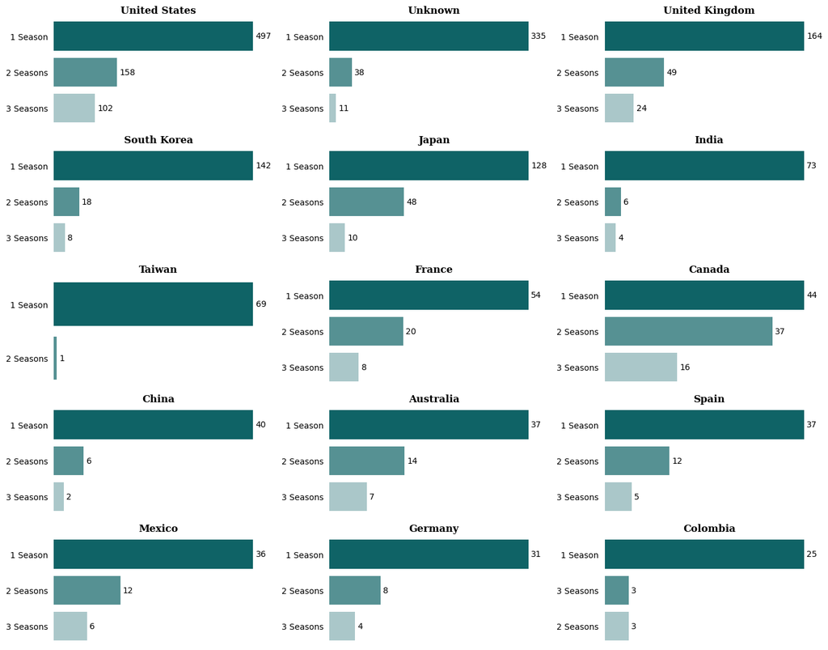

```python
countries = (
    top_3_seasons_per_country_shows
    .sort_values(['count', 'country', 'rank'], ascending=[False, True, True])['country']
    .unique()
)

n_cols = 3
n_rows = int(np.ceil(len(countries)/ n_cols))

fig, axes = plt.subplots(n_rows, n_cols, figsize=(14, 2.2 * n_rows))
axes = axes.flatten()

for i, country in enumerate(countries):

  data = ( top_3_seasons_per_country_shows[
      top_3_seasons_per_country_shows['country'] == country
  ]
  .sort_values('rank') )

  colors = ['#007074', '#4C9A9D', '#A5CCCE']

  sns.barplot(
      data=data,
      x='count',
      y='duration',
      hue='duration',
      ax=axes[i],
      palette=colors
  )

  axes[i].set_title(
        country,
        fontsize=12,
        fontweight='bold',
        fontfamily='serif'
    )

  axes[i].set_xlabel('')
  axes[i].set_ylabel('')
  axes[i].set_xticks([])

  sns.despine(ax=axes[i], left=True, bottom=True)
  axes[i].tick_params(left=False, bottom=False)

  for container in axes[i].containers:
        axes[i].bar_label(container, fmt='%d', padding=3)



plt.tight_layout()
plt.show()
```

Q5. What is CAGR for TV Shows in Netflix.

```python
tv_df.info()
```

```
<class 'pandas.core.frame.DataFrame'>
Index: 2664 entries, 1 to 8803
Data columns (total 8 columns):
 #   Column         Non-Null Count  Dtype
---  ------         --------------  -----
 0   show_id        2664 non-null   object
 1   title          2664 non-null   object
 2   country        2664 non-null   object
 3   date_added     2664 non-null   datetime64[ns]
 4   release_year   2664 non-null   int64
 5   listed_in      2664 non-null   object
 6   duration       2664 non-null   object
 7   no_of_seasons  2664 non-null   int64
dtypes: datetime64[ns](1), int64(2), object(5)
memory usage: 187.3+ KB
```

```python
tv_yearly = (
    tv_df
    .assign(year_added=lambda x: x['date_added'].dt.year)
    .groupby('year_added')
    .size()
    .reset_index(name='count')
    .sort_values('year_added')
)
```

```python
tv_yearly = tv_yearly[
    (tv_yearly['year_added'] >= 2015) &
    (tv_yearly['year_added'] <= 2020)
]
```

```python
print(tv_yearly)
```

```
   year_added  count
3        2015     26
4        2016    175
5        2017    349
6        2018    411
7        2019    592
8        2020    595
```

```python
begin_value = tv_yearly.iloc[0]['count']
end_value = tv_yearly.iloc[-1]['count']

num_years = (
    tv_yearly.iloc[-1]['year_added'] -
    tv_yearly.iloc[0]['year_added']
)

cagr_tv = ((end_value / begin_value) ** (1 / num_years) - 1) * 100

print(f"TV Shows CAGR (2015–2020): {cagr_tv:.2f}%")
```

```
TV Shows CAGR (2015–2020): 87.03%
```

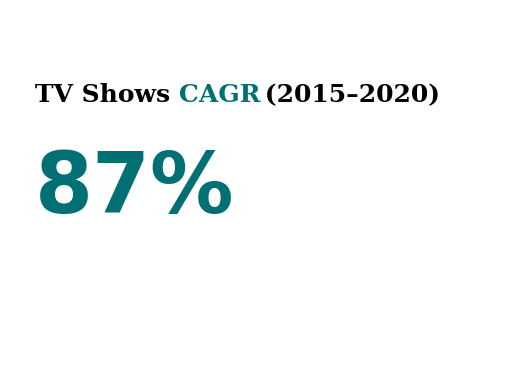

```python
ax = plt.gca()

# Remove everything
ax.set_xticks([])
ax.set_yticks([])
for spine in ax.spines.values():
    spine.set_visible(False)

# Add main title
plt.text(
    0.05, 0.75,
    "TV Shows ",
    fontsize=18,
    fontweight='semibold',
    fontfamily='serif',
    transform=ax.transAxes
)

# Add big percentage
plt.text(
    0.05, 0.45,
    "87%",
    fontsize=60,
    fontweight='bold',
    color='#007074',
    transform=ax.transAxes
)

plt.text(
    0.34, 0.75,
    "CAGR",
    fontsize=18,
    color='#007074',
    fontweight='semibold',
    fontfamily='serif',
    transform=ax.transAxes
)

plt.text(
    0.495, 0.75,
    " (2015–2020)",
    fontsize=18,
    fontweight='semibold',
    fontfamily='serif',
    transform=ax.transAxes
)

plt.show()
```

- From 2015 to 2020, TV shows grew at a faster rate (87%) compared to movies (61.6%). This shows that Netflix focused more on adding TV series during its expansion period. TV shows likely helped the platform keep users engaged for longer.

## Overall Insights :

1. Movies were heavily used during 2016–2019 to rapidly expand content volume. TV shows are more concentrated geographically and are dominated by single-season formats. Movies are a scalable toll where as the TV shows are viewer retention tool.
2. International Movies and International TV Shows dominate globally. This shows Netflix relies heavily on globally adaptable content.
3. Dramas and Comedies are consistently strong genres both in Movies and TV shows globally.
4. There were heavy local genre preferences like Anime in JAPAN, Korean TV shows in Korea and same for UK and Spain.
5. 17+ ratings dominate in major markets. Children-focused genres are concentrated in specific markets. Family content exists but not on driver level.
6. Movies of Standard length of 80-120 mins were produced majorly and TV shows with only one season appeared to be most produced.
7. The platform experienced hyper-growth between 2015–2020, especially in TV content. However, such high growth rates are unlikely to be sustainable long term. This suggests that Netflix may shift from rapid content expansion to optimizing content quality, engagement, and profitability.